[figure not shown]

# Statistical Design and Analysis of a Non-Inferiority Clinical Trial- BioMimics 3D Vascular Stent

### Áine Glynn, Filip Kłosowski<sup>1</sup>

##### <sup>1</sup> School of Mathematical and Statistical Sciences, University of Galway

# Background and Problem

## Objectives of Project

1. To define and justify a non-inferiority margin for a BioMimics 3D stent using historical and published evidence.
2. To develop statistically appropriate non-inferiority trial design parameters from a bio statistical perspective.
3. Develop a Shiny app to determine and visualize different sample size requirements under varying design assumptions and inferiority margins.
4. To analyse and interpret simulated trial data and evaluate non-inferiority conclusions.
5. To critically reflect on the limitations and assumptions inherent to non-inferiority designs.

# Definitions

# Case-study: Biomimics 3D stent

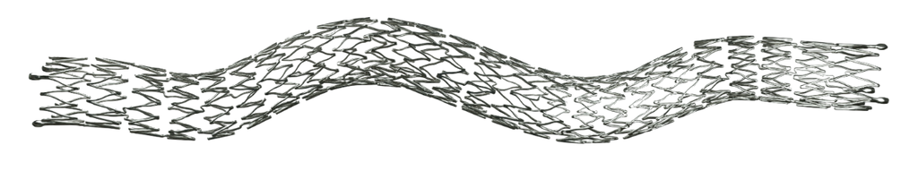

## Meta-analysis

# Margin-Jinn

Margin-Jinn is an interactive Shiny application developed as part of our project in order to support the statistical planning of non-inferiority clinical trials. The application enables visual exploration of sample size requirements across several different design parameters. Through dynamic plots and real-time updates, the app highlights the sensitivity of sample size modelling assumptions that are often fixed or under-examined during trial planning.

In our project Margin-Jinn is applied to the BioMimics 3D vascular stent to explore, justify and critically assess sample size choices under realistic design scenarios, reflecting the role of statistical decision-making in early-stage clinical trial design.

[figure not shown]

Find Margin-Jinn on github:: https://github.com/FilipMKgit/Margin-Jinn

# Next Project Steps

- Extend the BioMimics 3D case-study through simulation of non-inferiority trial data under realistic design assumptions.
- Analyse simulated trial outcomes to assess non-inferiority conclusions for the proposed stent design.
- Further explore the assumptions, limitations, and interpretational caveats inherent to non-inferiority clinical trials.